# Manual

Svetlana Koroteeva

2023-10-21

# MusicFeatClassR package

## Description

The MusicFeatClassR package aims to provide an end-to-end solution for music genre classification using Machine Learning (ML) techniques. The primary problem it addresses is automating the process of music genre classification, which involves extracting essential features from music datasets and training ML classifiers to predict the genre of music.

The MusicFeatClassR package consists of two main separate parts: feature extraction and classification.

## Feature extraction

It also has specific data requirements. The music dataset consists of Dissemination Information Packages (DIP) extracted from a Library preservation system based on OAIS. Another important file is “ies_mms_label.txt,” which contains identification numbers and class labels extracted from the library system (Note: Collecting class labels from the library system is not yet implemented).

For preparation, place the music dataset in the “files/mp3” folder and the “ies_mms_label.txt” file in the “inst/csv” folder. You can find all code examples in the “inst/scripts” folder. Currently, only mp3 feature extraction is implemented.

Please note that the example dataset contains only 10 DIP folders. It is not sufficient for classification but serves as a test to ensure that feature extraction is working.

To initiate the feature extraction process, you can either run the “run_extraction.R” script or copy the following code snippet. This script will extract features from the music dataset, extract text metadata from “ie.xml” files (inside each DIP), and match them with labels from your “mms_ies_label.txt” file. It will create one metadata row for each music file, bind them to the main data frame, write the data frame to a CSV output file (“extracted_features.csv”), and return the data frame. Let’s get started.

Ensure that you have loaded all the necessary libraries.

```r
library(xml2)
library(dplyr)
library(purrr)
library(tuneR)
library(data.table)
library(reshape2)
library(MusicFeatClassR) # the package
```

Here, you can customize the names of the output and input files, which contain labels. Before running the main pipeline, you should specify label_file_path, csv_file_path, and filesdir (for music packages).

```r
csv_file_name<-"extracted_features.csv"
label_file<-"ies_mms_label.txt"
vignettes_dir<-getwd()
parent_dir<-dirname(vignettes_dir)

csv_files_path<-file.path(parent_dir, "inst","csv")
csv_file_path<- file.path(csv_files_path, csv_file_name)
label_file_path<-file.path(csv_files_path, label_file)
filesdir <- file.path(parent_dir,'files','mp3')
```

Now you can initiate the pipeline. The entire process may take a couple of hours on the original dataset (please note that the example dataset only contains 10 albums). If the process is interrupted, the script will pick up from the last processed DIP folder in the next run.

```r
mydata<-rpipeline(label_file_path, csv_file_path, filesdir)
```

```
#>  [1] "IE1005520" "IE1005765" "IE1006254" "IE1010462" "IE1010492" "IE1013111"
#>  [7] "IE1013172" "IE1017243" "IE1017247" "IE1017269"
#> [1] "IE1005520"
#> [1] "IE number"
#> [1] "IE1005765"
#> [1] "IE number"
#> [1] "IE1006254"
#> [1] "IE number"
#> [1] "IE1010462"
#> [1] "IE number"
#> [1] "IE1010492"
#> [1] "IE number"
#> [1] "IE1013111"
#> [1] "IE number"
#> [1] "IE1013172"
```

[output cut: 34 more lines]

```r
head(mydata)
```

```
#> $label_file_path
#> [1] "C:/Users/Korotesv/DATA501/MusicFeatClassR/inst/csv/ies_mms_label.txt"
#>
#> $csv_file_path
#> [1] "C:/Users/Korotesv/DATA501/MusicFeatClassR/inst/csv/extracted_features.csv"
#>
#> $root_dir
#> [1] "C:/Users/Korotesv/DATA501/MusicFeatClassR/files/mp3"
#>
#> $feature_data
#>    X file_type ie_number...3  rep_number                     file_name duration
#> 1  1       mp3     IE1017269 REP74080121 FL74080122_1212219_PM_S_1.mp3  309.912
#> 2  2       mp3     IE1017269 REP74080121 FL74080125_1212219_PM_S_2.mp3  338.808
#> 3 NA       mp3          <NA> REP74080121 FL74080122_1212219_PM_S_1.mp3  309.912
#> 4 NA       mp3          <NA> REP74080121 FL74080125_1212219_PM_S_2.mp3  338.808
#>   sample_rate num_channels amplitude         xml_title
#> 1       48000     14875776     14070 The Kini Quartet.
#> 2       48000     16262784     20921 The Kini Quartet.
#> 3       48000     14875776     14070 The Kini Quartet.
#> 4       48000     16262784     20921 The Kini Quartet.
#>                          xml_creators         xml_type
#> 1 Kini Quartet.||Raggett, Margarette. Sound Recordings
#> 2 Kini Quartet.||Raggett, Margarette. Sound Recordings
#> 3 Kini Quartet.||Raggett, Margarette. Sound Recordings
#> 4 Kini Quartet.||Raggett, Margarette. Sound Recordings
#>                            xml_publisher xml_date xml_language xml_identifier
#> 1 Auckland, N.Z. :               Zodiac,   [1967]          mao      IE1017269
#> 2 Auckland, N.Z. :               Zodiac,   [1967]          mao      IE1017269
#> 3 Auckland, N.Z. :               Zodiac,   [1967]          mao      IE1017269
#> 4 Auckland, N.Z. :               Zodiac,   [1967]          mao      IE1017269
#>   xml_bibliographicCitation          mms ie_number...19 label_code
#> 1         The Kini Quartet. 9.912122e+15      IE1017269         pp
#> 2         The Kini Quartet. 9.912122e+15      IE1017269         pp
#> 3         The Kini Quartet. 9.912122e+15           <NA>         pp
#> 4         The Kini Quartet. 9.912122e+15           <NA>         pp
#>          label1        label2 label3 label4 label5 ie_number...2 ie_number...18
#> 1 Popular music Songs, Māori.   <NA>   <NA>   <NA>          <NA>           <NA>
#> 2 Popular music Songs, Māori.   <NA>   <NA>   <NA>          <NA>           <NA>
#> 3 Popular music Songs, Māori.                          IE1017269      IE1017269
#> 4 Popular music Songs, Māori.                          IE1017269      IE1017269
```

For the purpose of data analysis, three S3 class methods for ‘rpipeline’ were developed: ‘print,’ ‘summary,’ and ‘plot.’

Currently, they are in a ‘draft’ stage and will be further developed for the complete package. (Note: To test the ‘plot’ S3 method, you need to load the ‘plot.rpipeline’ function into memory first, as it may not work well within the package.)

```r
print(mydata)
```

```
#> Custom rpipeline object
#> Label File Path: C:/Users/Korotesv/DATA501/MusicFeatClassR/inst/csv/ies_mms_label.txt
#> CSV File Path: C:/Users/Korotesv/DATA501/MusicFeatClassR/inst/csv/extracted_features.csv
#> Root Directory: C:/Users/Korotesv/DATA501/MusicFeatClassR/files/mp3
#> Feature Data Summary:
#>    X file_type ie_number...3  rep_number                     file_name duration
#> 1  1       mp3     IE1017269 REP74080121 FL74080122_1212219_PM_S_1.mp3  309.912
#> 2  2       mp3     IE1017269 REP74080121 FL74080125_1212219_PM_S_2.mp3  338.808
#> 3 NA       mp3          <NA> REP74080121 FL74080122_1212219_PM_S_1.mp3  309.912
#> 4 NA       mp3          <NA> REP74080121 FL74080125_1212219_PM_S_2.mp3  338.808
#>   sample_rate num_channels amplitude         xml_title
#> 1       48000     14875776     14070 The Kini Quartet.
#> 2       48000     16262784     20921 The Kini Quartet.
#> 3       48000     14875776     14070 The Kini Quartet.
#> 4       48000     16262784     20921 The Kini Quartet.
#>                          xml_creators         xml_type
#> 1 Kini Quartet.||Raggett, Margarette. Sound Recordings
#> 2 Kini Quartet.||Raggett, Margarette. Sound Recordings
#> 3 Kini Quartet.||Raggett, Margarette. Sound Recordings
#> 4 Kini Quartet.||Raggett, Margarette. Sound Recordings
#>                            xml_publisher xml_date xml_language xml_identifier
#> 1 Auckland, N.Z. :               Zodiac,   [1967]          mao      IE1017269
#> 2 Auckland, N.Z. :               Zodiac,   [1967]          mao      IE1017269
#> 3 Auckland, N.Z. :               Zodiac,   [1967]          mao      IE1017269
#> 4 Auckland, N.Z. :               Zodiac,   [1967]          mao      IE1017269
#>   xml_bibliographicCitation          mms ie_number...19 label_code
#> 1         The Kini Quartet. 9.912122e+15      IE1017269         pp
#> 2         The Kini Quartet. 9.912122e+15      IE1017269         pp
#> 3         The Kini Quartet. 9.912122e+15           <NA>         pp
#> 4         The Kini Quartet. 9.912122e+15           <NA>         pp
#>          label1        label2 label3 label4 label5 ie_number...2 ie_number...18
#> 1 Popular music Songs, Māori.   <NA>   <NA>   <NA>          <NA>           <NA>
#> 2 Popular music Songs, Māori.   <NA>   <NA>   <NA>          <NA>           <NA>
#> 3 Popular music Songs, Māori.                          IE1017269      IE1017269
#> 4 Popular music Songs, Māori.                          IE1017269      IE1017269
```

```r
summary(mydata)
```

```
#> Summary of rpipeline object
#> Label File Path: C:/Users/Korotesv/DATA501/MusicFeatClassR/inst/csv/ies_mms_label.txt
#> CSV File Path: C:/Users/Korotesv/DATA501/MusicFeatClassR/inst/csv/extracted_features.csv
#> Root Directory: C:/Users/Korotesv/DATA501/MusicFeatClassR/files/mp3
#> Feature Data Summary:
#>        X         file_type         ie_number...3       rep_number
#>  Min.   :1.00   Length:4           Length:4           Length:4
#>  1st Qu.:1.25   Class :character   Class :character   Class :character
#>  Median :1.50   Mode  :character   Mode  :character   Mode  :character
#>  Mean   :1.50
#>  3rd Qu.:1.75
#>  Max.   :2.00
#>  NA's   :2
#>   file_name            duration      sample_rate     num_channels
#>  Length:4           Min.   :309.9   Min.   :48000   Min.   :14875776
#>  Class :character   1st Qu.:309.9   1st Qu.:48000   1st Qu.:14875776
#>  Mode  :character   Median :324.4   Median :48000   Median :15569280
#>                     Mean   :324.4   Mean   :48000   Mean   :15569280
#>                     3rd Qu.:338.8   3rd Qu.:48000   3rd Qu.:16262784
#>                     Max.   :338.8   Max.   :48000   Max.   :16262784
#>
#>    amplitude      xml_title         xml_creators         xml_type
#>  Min.   :14070   Length:4           Length:4           Length:4
#>  1st Qu.:14070   Class :character   Class :character   Class :character
#>  Median :17496   Mode  :character   Mode  :character   Mode  :character
#>  Mean   :17496
#>  3rd Qu.:20921
#>  Max.   :20921
#>
#>  xml_publisher        xml_date         xml_language       xml_identifier
#>  Length:4           Length:4           Length:4           Length:4
#>  Class :character   Class :character   Class :character   Class :character
#>  Mode  :character   Mode  :character   Mode  :character   Mode  :character
#>
#>
#>
#>
#>  xml_bibliographicCitation      mms            ie_number...19
#>  Length:4                  Min.   :9.912e+15   Length:4
#>  Class :character          1st Qu.:9.912e+15   Class :character
#>  Mode  :character          Median :9.912e+15   Mode  :character
#>                            Mean   :9.912e+15
#>                            3rd Qu.:9.912e+15
#>                            Max.   :9.912e+15
#>
#>   label_code           label1             label2             label3
#>  Length:4           Length:4           Length:4           Length:4
#>  Class :character   Class :character   Class :character   Class :character
#>  Mode  :character   Mode  :character   Mode  :character   Mode  :character
#>
#>
#>
#>
#>     label4             label5          ie_number...2      ie_number...18
#>  Length:4           Length:4           Length:4           Length:4
#>  Class :character   Class :character   Class :character   Class :character
#>  Mode  :character   Mode  :character   Mode  :character   Mode  :character
#>
#>
#>
#>
```

Note: Currently “plot” does not load correctly, so I copied the script here

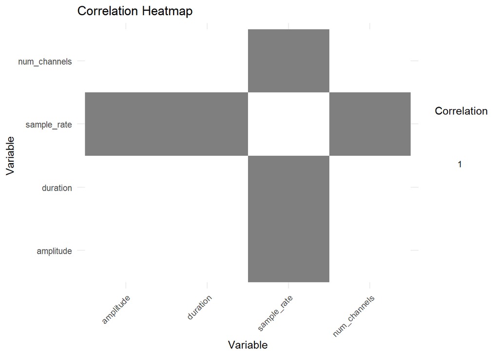

```r
plot(mydata)
```

## Classification

In addition to Random Forest, which is considered one of the best classifiers, the package also includes Naive Bayes, Support Vector Machine, and Logistic Regression methods. You can call the specific method by replacing “RandomForest” with “LogisticRegression,” “NaiveBayes,” or “SupportVectorMachine.”

To initiate the classification process, you can use the “classify.R” code from the “inst/scripts” directory or copy it from the code snippets.

```r
library(randomForest)
library(caret)
library(data.table)
library(stringr)
library(e1071)
library(nnet)
library(Rcpp)
library(MusicFeatClassR)
csv_file_name<-"extracted_features_original.csv"
vignettes_dir<-getwd()
parent_dir<-dirname(vignettes_dir)
csv_files_path<-file.path(parent_dir, "inst","csv")
csv_file_path<-file.path(csv_files_path, csv_file_name)
feature_data<-read.csv(csv_file_path)
result <- train_classifier(feature_data ,classif = "RandomForest")
model_path<-file.path(parent_dir, "inst", "model.rds")
#the model can be saved
saveRDS(result$trained_model, file = model_path)
```

Class result also has print and summary methods

```r
print(result)
```

```
#> $accuracy
#> [1] 0.7263441
#>
#> $confusion_matrix
#> Confusion Matrix and Statistics
#>
#>           Reference
#> Prediction  bl  cy  df  fm  jz  pp  rc  sg  uu  zz
#>         bl  12   0   0   0   0   0   0   0   0   2
#>         cy   0  17   0   0   0   2   1   0   0   2
#>         df   0   1  44   0   3   5   4   0   0   9
#>         fm   0   0   0  26   1   3   4   4   0   2
#>         jz   0   0   2   2  52   2   5   0   0   1
#>         pp   1   0   2   2   1 120  20   7   1  13
#>         rc   0   6  13   4   9  35 411   9   5  60
#>         sg   0   2   0   4   0   5   2   8   1   2
#>         uu   0   0   0   0   1   0   2   1   0   1
#>         zz   0   1  26   7   7  52 134   8  10 661
#>
#> Overall Statistics
#>
#>                Accuracy : 0.7263
#>                  95% CI : (0.7055, 0.7465)
#>     No Information Rate : 0.4048
#>     P-Value [Acc > NIR] : < 2.2e-16
#>
#>                   Kappa : 0.6062
#>
#>  Mcnemar's Test P-Value : NA
#>
#> Statistics by Class:
#>
#>                      Class: bl Class: cy Class: df Class: fm Class: jz
#> Sensitivity           0.923077   0.62963   0.50575   0.57778   0.70270
#> Specificity           0.998917   0.99727   0.98759   0.99229   0.99328
#> Pos Pred Value        0.857143   0.77273   0.66667   0.65000   0.81250
#> Neg Pred Value        0.999458   0.99456   0.97603   0.98956   0.98775
#> Prevalence            0.006989   0.01452   0.04677   0.02419   0.03978
#> Detection Rate        0.006452   0.00914   0.02366   0.01398   0.02796
#> Detection Prevalence  0.007527   0.01183   0.03548   0.02151   0.03441
```

[output cut: 257 more lines]

```
#>   zz   rc   zz   zz   zz   zz   rc   zz   rc   zz   zz   rc   zz   zz   rc   zz
#> 6461 6462 6466 6469 6470 6471 6475 6477 6480 6484 6485 6496 6505 6509 6513 6515
#>   zz   sg   rc   rc   zz   zz   rc   rc   zz   zz   cy   rc   zz   rc   pp   zz
#> 6518 6526 6529 6534 6539 6541 6542 6550 6551 6554 6556 6557 6558 6559 6561 6565
#>   sg   zz   zz   pp   zz   zz   sg   sg   uu   sg   zz   rc   zz   fm   sg   rc
#> 6575 6576 6577 6578 6579 6582 6583 6587 6591 6593 6595 6596 6597 6598 6602 6603
#>   sg   zz   jz   sg   zz   zz   rc   sg   sg   zz   pp   zz   rc   zz   zz   rc
#> 6604 6606 6614 6618 6621 6622 6629 6632 6637 6641 6646 6660 6663 6664 6666 6669
#>   zz   zz   zz   bl   zz   zz   zz   zz   zz   pp   sg   fm   fm   zz   pp   zz
#> 6676 6678 6679 6694
#>   rc   rc   pp   pp
#> Levels: bl cy df fm jz pp rc sg uu zz
#>
#> attr(,"class")
#> [1] "train_classifier"
```

```r
summary(result)
```

```
#>                  Length Class                Mode
#> accuracy            1   -none-               numeric
#> confusion_matrix    6   confusionMatrix      list
#> trained_model      19   randomForest.formula list
#> predictions      1860   factor               numeric
```

[figure not shown]

```r
plot(result)
```

### RCPP code

The package also contains c++ method which build additional statistics using confusion matrix from results: [Matthews correlation coefficient (MCC)](https://en.wikipedia.org/wiki/Phi_coefficient) and [F1-score](https://en.wikipedia.org/wiki/F-score). The original script is in “src/get_metrics.cpp”. It is taking as input the table derived from confusion matrix. See example below.

```r
#sourceCpp(parent_dir,"src","get_metrics.cpp")
classificationMetrics(result$confusion_matrix$table)
```

```
#> F1_Score      MCC
#>      NaN 0.557277
```

### Other classifiers and additional parameters.

You can learn more about parameters in the following functions/libraries documentation - randomForest, naiveBayes, svm (e1071 library), multinom (standard R library)

classifier_name <- “RandomForest” classifier_params <- list( ntree = 2000,  
mtry = 4  
)

classifier_name <- “LogisticRegression” classifier_params<- list( family = “binomial”, maxit = 10000, tol = 1e-5, lambda = 0.1, alpha = 0.5 )

result <- train_classifier(feature_data, classif = classifier_name, classif_params = classifier_params) result$accuracy

classifier_name<- “SupportVectorMachine” classifier_params <- list( kernel = “linear”, cost = 1.0, gamma = 0.01, degree = 3, coef0 = 0 )

result <- train_classifier(feature_data, classif = classifier_name, classif_params = classifier_params)

result$accuracy

classifier_name_naive_bayes <- “NaiveBayes” classifier_params_naive_bayes <- list( laplace = 1, usekernel = TRUE, fL = 0.01, adjust = 1 )

result <- train_classifier(feature_data, classif = classifier_name, classif_params = classifier_params)

result$accuracy